# 重賞レース予測レポート【毎時自動更新中】

作成日時: 2026/06/14 14:05:53

☞ [マニュアル(pdf)](https://ryutoro-galois.github.io/keiba-predictor/manual/manual.pdf)

☞ 過去6年の同一レース結果: [2025年](https://ryutoro-galois.github.io/keiba-predictor/report/PredResult_2025y_raceDate_20250614_20250615.html), [2024年](https://ryutoro-galois.github.io/keiba-predictor/report/PredResult_2024y_raceDate_20240609_20240609.html), [2023年](https://ryutoro-galois.github.io/keiba-predictor/report/PredResult_2023y_raceDate_20230611_20230611.html), [2022年](https://ryutoro-galois.github.io/keiba-predictor/report/PredResult_2022y_raceDate_20220612_20220612.html), [2021年](https://ryutoro-galois.github.io/keiba-predictor/report/PredResult_2021y_raceDate_20210613_20210613.html), [2020年](https://ryutoro-galois.github.io/keiba-predictor/report/PredResult_2020y_raceDate_20200614_20200614.html)

☞ 過去4週間の別レース結果: [1週前(6/7)](https://ryutoro-galois.github.io/keiba-predictor/report/PredResult_2026y_raceDate_20260607_20260607.html), [2週前(5/30-31)](https://ryutoro-galois.github.io/keiba-predictor/report/PredResult_2026y_raceDate_20260530_20260531.html), [3週前(5/23-24)](https://ryutoro-galois.github.io/keiba-predictor/report/PredResult_2026y_raceDate_20260523_20260524.html), [4週前(5/16-17)](https://ryutoro-galois.github.io/keiba-predictor/report/PredResult_2026y_raceDate_20260516_20260517.html)

☞ netkeiba: [東京ジャンプステークス(JGⅢ)](https://race.netkeiba.com/race/shutuba.html?race_id=202605030304&rf=race_list), [函館スプリントステークス(GⅢ)](https://race.netkeiba.com/race/shutuba.html?race_id=202602010111&rf=race_list), [宝塚記念(GⅠ)](https://race.netkeiba.com/race/shutuba.html?race_id=202609030411&rf=race_list)

## 0. 推し馬予測 (AI予測)

### 【東京ジャンプステークス(J.GⅢ) 2026/06/13(土)】

- 本命(◎): 1-3着内確率(勝負強さ)が1位の馬
- 対抗(◯): 1-3着内確率が2-N位(20%程度以上)の中で予測タイムが最も速い馬
- 3番手(▲): 1-3着内確率が2-N位(20%程度以上)のでダークホース確率が最も高い馬
- 穴: ダークホース確率が上位1-M位(40%程度以上)の中で1-3着内確率が最も高い馬

| 推し馬 | 枠番 | 馬番 | 人気 | オッズ | 馬名 | 騎手 | 調教師 | 予測タイム(sec) | 1_順位 | 1-3着内確率(%) | 2_順位 | ﾀﾞｰｸﾎｰｽ確率(%) | 3_順位 |
| --- | --- | --- | --- | --- | --- | --- | --- | --- | --- | --- | --- | --- | --- |
| 本命(◎) | 1 | 1 | 2 | 8.5 | ピーターサイト | 上野翔 | 村田一誠 | 220.4 | 3 | 21.3 | 1 | 1.4 | 8 |
| 対抗(◯) | 8 | 9 | 1 | 1.2 | ジューンベロシティ | 高田潤 | 武英智 | 205.3 | 1 | 13.9 | 2 | 0.4 | 10 |
| 3番手(▲) | 6 | 6 | 8 | 53.7 | ブラックボイス | 坂口智康 | 浅利英明 | 214.3 | 2 | 10.6 | 4 | 28.9 | 1 |
| 穴 | 4 | 4 | 5 | 19.8 | ローディアマント | 伴啓太 | 尾関知人 | 220.7 | 4 | 9.9 | 5 | 1.8 | 6 |

### 【函館スプリントステークス(GⅢ) 2026/06/13(土)】

- 本命(◎): 1-3着内確率(勝負強さ)が1位の馬
- 対抗(◯): 1-3着内確率が2-N位(20%程度以上)の中で予測タイムが最も速い馬
- 3番手(▲): 1-3着内確率が2-N位(20%程度以上)のでダークホース確率が最も高い馬
- 穴: ダークホース確率が上位1-M位(40%程度以上)の中で1-3着内確率が最も高い馬

| 推し馬 | 枠番 | 馬番 | 人気 | オッズ | 馬名 | 騎手 | 調教師 | 予測タイム(sec) | 1_順位 | 1-3着内確率(%) | 2_順位 | ﾀﾞｰｸﾎｰｽ確率(%) | 3_順位 |
| --- | --- | --- | --- | --- | --- | --- | --- | --- | --- | --- | --- | --- | --- |
| 本命(◎) | 4 | 4 | 2 | 4.6 | カルプスペルシュ | 丹内祐次 | 石坂公一 | 71.6 | 7 | 61.6 | 1 | 0.4 | 11 |
| 対抗(◯) | 7 | 11 | 5 | 7.8 | インビンシブルパパ | 佐々木大輔 | 伊藤大士 | 70.9 | 4 | 22.5 | 2 | 1.1 | 7 |
| 3番手(▲) | 6 | 8 | 7 | 19.9 | ポッドベイダー | 荻野極 | 上原佑紀 | 71.0 | 5 | 13.0 | 6 | 26.7 | 5 |
| 穴 | 4 | 5 | 10 | 31.1 | ジョーメッドヴィン | 横山琉人 | 清水久詞 | 70.6 | 3 | 9.2 | 7 | 47.2 | 1 |

### 【宝塚記念(GⅠ) 2026/06/14(日)】

- 本命(◎): 1-3着内確率(勝負強さ)が1位の馬
- 対抗(◯): 1-3着内確率が2-N位(20%程度以上)の中で予測タイムが最も速い馬
- 3番手(▲): 1-3着内確率が2-N位(20%程度以上)のでダークホース確率が最も高い馬
- 穴: ダークホース確率が上位1-M位(40%程度以上)の中で1-3着内確率が最も高い馬

| 推し馬 | 枠番 | 馬番 | 人気 | オッズ | 馬名 | 騎手 | 調教師 | 予測タイム(sec) | 1_順位 | 1-3着内確率(%) | 2_順位 | ﾀﾞｰｸﾎｰｽ確率(%) | 3_順位 |
| --- | --- | --- | --- | --- | --- | --- | --- | --- | --- | --- | --- | --- | --- |
| 本命(◎) | 3 | 5 | 1 | 2.4 | クロワデュノール | 北村友一 | 斉藤崇史 | 130.1 | 1 | 39.8 | 1 | 0.7 | 14 |
| 対抗(◯) | 8 | 17 | 4 | 6.5 | レガレイラ | Ｃ．ルメール | 木村哲也 | 132.2 | 3 | 27.0 | 2 | 0.6 | 15 |
| 3番手(▲) | 7 | 15 | 6 | 17.3 | マイユニバース | 横山典弘 | 武幸四郎 | 142.2 | 18 | 21.9 | 5 | 1.9 | 10 |
| 穴 | 5 | 10 | 15 | 176.0 | ジューンテイク | 松山弘平 | 武英智 | 134.9 | 7 | 10.8 | 11 | 49.3 | 3 |

## 1. 予測チャート (タイム/勝負強さ)

### 【東京ジャンプステークス(J.GⅢ)】

2026/06/13(土), 05_東京, 障芝3110m

[interactive chart not shown]

### 【函館スプリントステークス(GⅢ)】

2026/06/13(土), 02_函館, 芝右1200m

[interactive chart not shown]

### 【宝塚記念(GⅠ)】

2026/06/14(日), 09_阪神, 芝右2200m

[interactive chart not shown]

## 2. オッズモニタリング (毎時)

### 【東京ジャンプステークス】

[interactive chart not shown]

### 【函館スプリントステークス】

[interactive chart not shown]

### 【宝塚記念】

[interactive chart not shown]

## 3. 出馬表

### 【東京ジャンプステークス 2026/06/13(土) 】

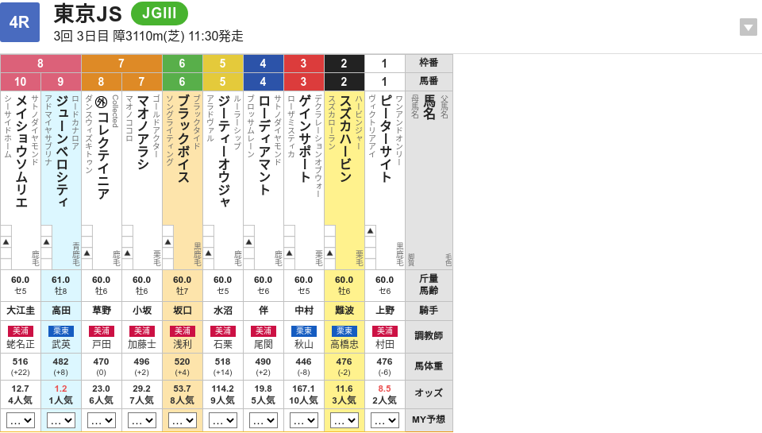

### 【函館スプリントステークス 2026/06/13(土) 】

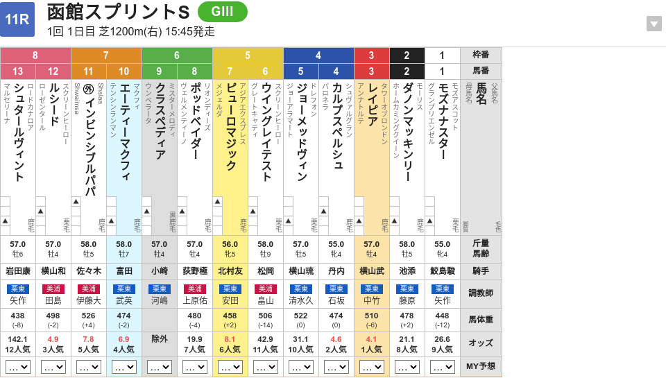

### 【宝塚記念 2026/06/14(日) 】

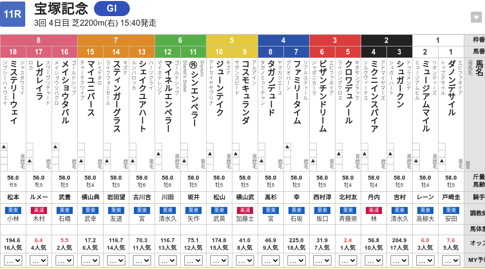

## 4. 単勝予測結果

### 【東京ジャンプステークス(J.GⅢ) 2026/06/13(土)】

| 枠番 | 馬番 | 人気 | オッズ | 馬名 | 騎手 | 調教師 | 予測タイム(sec) | 1_順位 | 1-3着内確率(%) | 2_順位 | ﾀﾞｰｸﾎｰｽ確率(%) | 3_順位 |
| --- | --- | --- | --- | --- | --- | --- | --- | --- | --- | --- | --- | --- |
| 1 | 1 | 2 | 8.5 | ピーターサイト | 上野翔 | 村田一誠 | 220.4 | 3 | 21.3 | 1 | 1.4 | 8 |
| 2 | 2 | 3 | 11.6 | スズカハービン | 難波剛健 | 高橋義忠 | 223.1 | 7 | 11.0 | 3 | 1.2 | 9 |
| 3 | 3 | 10 | 167.1 | ゲインサポート | 中村将之 | 秋山真一郎 | 223.0 | 6 | 3.2 | 7 | 10.7 | 5 |
| 4 | 4 | 5 | 19.8 | ローディアマント | 伴啓太 | 尾関知人 | 220.7 | 4 | 9.9 | 5 | 1.8 | 6 |
| 5 | 5 | 9 | 114.2 | ジーティーオウジャ | 水沼元輝 | 石栗龍彦 | 226.5 | 9 | 1.7 | 10 | 15.8 | 4 |
| 6 | 6 | 8 | 53.7 | ブラックボイス | 坂口智康 | 浅利英明 | 214.3 | 2 | 10.6 | 4 | 28.9 | 1 |
| 7 | 7 | 7 | 29.2 | マオノアラシ | 小坂忠士 | 加藤士津八 | 222.5 | 5 | 3.0 | 8 | 21.7 | 2 |
| 7 | 8 | 6 | 23.0 | コレクテイニア | 草野太郎 | 戸田博文 | 227.3 | 10 | 2.5 | 9 | 17.7 | 3 |
| 8 | 9 | 1 | 1.2 | ジューンベロシティ | 高田潤 | 武英智 | 205.3 | 1 | 13.9 | 2 | 0.4 | 10 |
| 8 | 10 | 4 | 12.7 | メイショウソムリエ | 大江原圭 | 蛯名正義 | 223.2 | 8 | 7.7 | 6 | 1.4 | 7 |

### 【函館スプリントステークス(GⅢ) 2026/06/13(土)】

| 枠番 | 馬番 | 人気 | オッズ | 馬名 | 騎手 | 調教師 | 予測タイム(sec) | 1_順位 | 1-3着内確率(%) | 2_順位 | ﾀﾞｰｸﾎｰｽ確率(%) | 3_順位 |
| --- | --- | --- | --- | --- | --- | --- | --- | --- | --- | --- | --- | --- |
| 1 | 1 | 9 | 26.6 | モズナナスター | 鮫島克駿 | 矢作芳人 | 71.2 | 6 | 3.8 | 11 | 39.7 | 2 |
| 2 | 2 | 8 | 21.1 | ダノンマッキンリー | 池添謙一 | 藤原英昭 | 67.1 | 2 | 7.4 | 8 | 34.2 | 4 |
| 3 | 3 | 1 | 4.1 | レイピア | 横山武史 | 中竹和也 | 66.8 | 1 | 15.2 | 4 | 0.4 | 12 |
| 4 | 4 | 2 | 4.6 | カルプスペルシュ | 丹内祐次 | 石坂公一 | 71.6 | 7 | 61.6 | 1 | 0.4 | 11 |
| 4 | 5 | 10 | 31.1 | ジョーメッドヴィン | 横山琉人 | 清水久詞 | 70.6 | 3 | 9.2 | 7 | 47.2 | 1 |
| 5 | 6 | 11 | 42.9 | ウイングレイテスト | 松岡正海 | 畠山吉宏 | 79.9 | 12 | 4.8 | 10 | 21.7 | 6 |
| 5 | 7 | 6 | 8.1 | ピューロマジック | 北村友一 | 安田翔伍 | 75.9 | 8 | 5.3 | 9 | 0.8 | 8 |
| 6 | 8 | 7 | 19.9 | ポッドベイダー | 荻野極 | 上原佑紀 | 71.0 | 5 | 13.0 | 6 | 26.7 | 5 |
| 7 | 10 | 4 | 6.9 | エーティーマクフィ | 富田暁 | 武英智 | 77.5 | 11 | 14.3 | 5 | 0.7 | 9 |
| 7 | 11 | 5 | 7.8 | インビンシブルパパ | 佐々木大輔 | 伊藤大士 | 70.9 | 4 | 22.5 | 2 | 1.1 | 7 |

[output cut: 2 more lines]

### 【宝塚記念(GⅠ) 2026/06/14(日)】

| 枠番 | 馬番 | 人気 | オッズ | 馬名 | 騎手 | 調教師 | 予測タイム(sec) | 1_順位 | 1-3着内確率(%) | 2_順位 | ﾀﾞｰｸﾎｰｽ確率(%) | 3_順位 |
| --- | --- | --- | --- | --- | --- | --- | --- | --- | --- | --- | --- | --- |
| 1 | 1 | 5 | 7.5 | ダノンデサイル | 戸崎圭太 | 安田翔伍 | 135.2 | 10.0 | 17.5 | 7 | 0.6 | 17 |
| 1 | 2 | 3 | 6.0 | ミュージアムマイル | Ｄ．レーン | 高柳大輔 | 138.0 | 13.0 | 26.3 | 3 | 0.6 | 18 |
| 2 | 3 | 17 | 205.4 | シュガークン | 吉村誠之助 | 清水久詞 | 134.9 | 7.0 | 10.2 | 14 | 52.7 | 2 |
| 2 | 4 | 10 | 56.6 | ミクニインスパイア | 丹内祐次 | 林徹 | 141.2 | 17.0 | 4.6 | 17 | 42.1 | 4 |
| 3 | 5 | 1 | 2.4 | クロワデュノール | 北村友一 | 斉藤崇史 | 130.1 | 1.0 | 39.8 | 1 | 0.7 | 14 |
| 3 | 6 | 7 | 32.3 | ビザンチンドリーム | 西村淳也 | 坂口智康 | 134.9 | 7.0 | 24.6 | 4 | 1.7 | 11 |
| 4 | 7 | 18 | 224.3 | ファミリータイム | 幸英明 | 石坂公一 | 135.4 | 11.5 | 10.2 | 13 | 55.2 | 1 |
| 4 | 8 | 9 | 46.6 | タガノデュード | 高杉吏麒 | 宮徹 | 139.6 | 15.0 | 9.3 | 15 | 1.5 | 12 |
| 5 | 9 | 8 | 41.5 | コスモキュランダ | 横山武史 | 加藤士津八 | 139.8 | 16.0 | 12.5 | 8 | 1.2 | 13 |
| 5 | 10 | 15 | 176.0 | ジューンテイク | 松山弘平 | 武英智 | 134.9 | 7.0 | 10.8 | 11 | 49.3 | 3 |

[output cut: 8 more lines]

## 5. 人気と着順の乖離率推移

### 【東京ジャンプステークス_2009y_2019y】

[interactive chart not shown]

### 【函館スプリントステークス_1997y_2019y】

[interactive chart not shown]

### 【宝塚記念_1990y_2019y】

[interactive chart not shown]

### 【東京ジャンプステークス_2009y_2019y】

| No | 開催年 | 不整合率(%) | 頭数 | 人気別着順(1-3位) | 人気別着順(全体) |
| --- | --- | --- | --- | --- | --- |
| 11 | 2019 | 28.8 | 11頭 | 3-1-2 | 3\|1\|2\|5\|7\|6\|9\|10\|12\|11\|13 |
| 10 | 2018 | 77.0 | 11頭 | 10-7-6 | 10\|7\|6\|3\|4\|2\|8\|11\|9\|5\|1 |
| 9 | 2017 | 67.3 | 9頭 | 3-5-9 | 3\|5\|9\|7\|2\|4\|1\|6\|8 |
| 8 | 2016 | 27.2 | 14頭 | 1-11-7 | 1\|11\|7\|5\|2\|4\|10\|6\|3\|12\|9\|14\|8\|13 |
| 7 | 2015 | 60.6 | 14頭 | 3-5-6 | 3\|5\|6\|9\|2\|4\|7\|10\|1\|13\|12\|8\|14\|11 |
| 6 | 2014 | 35.5 | 14頭 | 2-4-13 | 2\|4\|13\|6\|10\|7\|1\|3\|5\|8\|11\|14\|12\|9 |
| 5 | 2013 | 24.6 | 14頭 | 4-1-6 | 4\|1\|6\|2\|14\|3\|5\|9\|7\|11\|12\|10\|13\|8 |
| 4 | 2012 | 22.9 | 14頭 | 1-8-6 | 1\|8\|6\|2\|14\|13\|5\|11\|3\|7\|10\|4\|9\|12 |
| 3 | 2011 | 41.6 | 12頭 | 8-12-9 | 8\|12\|9\|2\|13\|1\|5\|4\|10\|3\|14\|7 |
| 2 | 2010 | 29.8 | 14頭 | 1-9-7 | 1\|9\|7\|13\|4\|11\|12\|2\|8\|5\|3\|6\|10\|14 |

[output cut: 1 more lines]

### 【函館スプリントステークス_1997y_2019y】

| No | 開催年 | 不整合率(%) | 頭数 | 人気別着順(1-3位) | 人気別着順(全体) |
| --- | --- | --- | --- | --- | --- |
| 23 | 2019 | 39.2 | 7頭 | 5-2-1 | 5\|2\|1\|4\|3\|7\|6 |
| 22 | 2018 | 34.9 | 16頭 | 3-10-1 | 3\|10\|1\|13\|11\|9\|16\|2\|4\|14\|5\|15\|7\|6\|12\|8 |
| 21 | 2017 | 50.5 | 13頭 | 3-4-7 | 3\|4\|7\|1\|11\|8\|10\|9\|5\|2\|12\|13\|6 |
| 20 | 2016 | 39.3 | 16頭 | 12-2-7 | 12\|2\|7\|3\|10\|1\|5\|8\|11\|15\|13\|4\|6\|14\|16\|9 |
| 19 | 2015 | 54.8 | 16頭 | 4-14-12 | 4\|14\|12\|7\|2\|9\|15\|6\|8\|5\|11\|13\|10\|1\|3\|16 |
| 18 | 2014 | 68.0 | 14頭 | 8-6-4 | 8\|6\|4\|5\|2\|9\|14\|12\|3\|7\|1\|11\|13\|10 |
| 17 | 2013 | 59.6 | 16頭 | 6-5-3 | 6\|5\|3\|7\|4\|8\|15\|1\|2\|11\|12\|13\|14\|9\|10\|16 |
| 16 | 2012 | 24.4 | 11頭 | 2-1-11 | 2\|1\|11\|3\|7\|5\|10\|6\|4\|9\|8 |
| 15 | 2011 | 28.6 | 12頭 | 1-3-2 | 1\|3\|2\|11\|9\|7\|6\|5\|10\|8\|4\|12 |
| 14 | 2010 | 27.8 | 15頭 | 2-1-5 | 2\|1\|5\|4\|3\|11\|10\|6\|8\|12\|15\|14\|9\|13\|7 |

[output cut: 13 more lines]

### 【宝塚記念_1990y_2019y】

| No | 開催年 | 不整合率(%) | 頭数 | 人気別着順(1-3位) | 人気別着順(全体) |
| --- | --- | --- | --- | --- | --- |
| 30 | 2019 | 41.5 | 12頭 | 3-1-6 | 3\|1\|6\|5\|2\|10\|8\|9\|4\|11\|7\|12 |
| 29 | 2018 | 46.1 | 16頭 | 7-10-12 | 7\|10\|12\|3\|5\|1\|11\|2\|4\|13\|8\|6\|15\|9\|16\|14 |
| 28 | 2017 | 68.5 | 11頭 | 3-5-4 | 3\|5\|4\|2\|7\|8\|9\|6\|1\|11\|10 |
| 27 | 2016 | 24.9 | 17頭 | 8-1-2 | 8\|1\|2\|4\|7\|9\|11\|10\|5\|17\|14\|16\|15\|13\|6\|3\|12 |
| 26 | 2015 | 68.1 | 16頭 | 6-10-11 | 6\|10\|11\|7\|3\|8\|12\|2\|13\|16\|4\|9\|5\|15\|1\|14 |
| 25 | 2014 | 28.1 | 12頭 | 1-9-8 | 1\|9\|8\|12\|6\|7\|2\|5\|3\|11\|4\|10 |
| 24 | 2013 | 25.7 | 11頭 | 2-5-1 | 2\|5\|1\|3\|4\|7\|8\|10\|11\|6\|9 |
| 23 | 2012 | 12.5 | 16頭 | 1-2-6 | 1\|2\|6\|3\|12\|4\|8\|13\|9\|7\|14\|5\|16\|11\|15\|10 |
| 22 | 2011 | 32.5 | 16頭 | 6-1-3 | 6\|1\|3\|5\|2\|10\|11\|16\|9\|7\|12\|13\|4\|8\|14\|15 |
| 21 | 2010 | 30.4 | 17頭 | 8-1-3 | 8\|1\|3\|4\|12\|13\|14\|2\|9\|6\|11\|15\|5\|16\|10\|7\|17 |

[output cut: 20 more lines]

## 6. 1-3番人気馬の着順分類予測

### 【東京ジャンプステークス】

| 分類 | 凡例 | 発生確率(%) | 当該レース | 当該レースランク | 直近1年間 |
| --- | --- | --- | --- | --- | --- |
| 1: 1番人気のみ (1_pop1) | 1 \| * \| * | 17.7 | 0.75 | 0.90 | 0.00 |
| 4: 1,2番人気のみ (4_pop12) | 1 \| 2 \| * | 17.6 | 0.00 | 0.74 | 0.53 |
| 8: 1,2,3番人気すべて着外 (8_darkhorse) | * \| * \| * | 13.7 | 1.16 | 1.57 | 0.00 |
| 5: 1,3番人気のみ (5_pop13) | 1 \| 3 \| * | 13.1 | 0.00 | 3.05 | 0.39 |
| 7: 1,2,3番人気すべて着内 (7_pop123) | 1 \| 2 \| 3 | 9.9 | 0.24 | 0.57 | 0.30 |
| 6: 2,3番人気のみ (6_pop23) | 2 \| 3 \| * | 9.7 | 0.00 | 2.26 | 0.00 |
| 2: 2番人気のみ (2_pop2) | 2 \| * \| * | 9.2 | 0.78 | 0.84 | 0.00 |
| 3: 3番人気のみ (3_pop3) | 3 \| * \| * | 9.0 | 0.76 | 0.83 | 0.00 |

### 【函館スプリントステークス】

| 分類 | 凡例 | 発生確率(%) | 当該レース | 当該レースランク | 直近1年間 |
| --- | --- | --- | --- | --- | --- |
| 4: 1,2番人気のみ (4_pop12) | 1 \| 2 \| * | 18.7 | 0.49 | 0.78 | 0.56 |
| 1: 1番人気のみ (1_pop1) | 1 \| * \| * | 18.1 | 1.05 | 0.92 | 0.00 |
| 8: 1,2,3番人気すべて着外 (8_darkhorse) | * \| * \| * | 14.1 | 2.04 | 1.62 | 0.00 |
| 5: 1,3番人気のみ (5_pop13) | 1 \| 3 \| * | 13.3 | 1.93 | 3.09 | 0.40 |
| 6: 2,3番人気のみ (6_pop23) | 2 \| 3 \| * | 10.0 | 1.45 | 2.33 | 0.00 |
| 3: 3番人気のみ (3_pop3) | 3 \| * \| * | 9.5 | 0.92 | 0.87 | 0.00 |
| 2: 2番人気のみ (2_pop2) | 2 \| * \| * | 9.3 | 0.90 | 0.85 | 0.00 |
| 7: 1,2,3番人気すべて着内 (7_pop123) | 1 \| 2 \| 3 | 7.1 | 2.09 | 0.41 | 0.21 |

### 【宝塚記念】

| 分類 | 凡例 | 発生確率(%) | 当該レース | 当該レースランク | 直近1年間 |
| --- | --- | --- | --- | --- | --- |
| 1: 1番人気のみ (1_pop1) | 1 \| * \| * | 17.7 | 1.06 | 1.06 | 0.00 |
| 4: 1,2番人気のみ (4_pop12) | 1 \| 2 \| * | 17.6 | 1.05 | 1.05 | 0.00 |
| 8: 1,2,3番人気すべて着外 (8_darkhorse) | * \| * \| * | 13.7 | 1.23 | 1.23 | 0.00 |
| 5: 1,3番人気のみ (5_pop13) | 1 \| 3 \| * | 13.1 | 0.30 | 0.30 | 0.13 |
| 7: 1,2,3番人気すべて着内 (7_pop123) | 1 \| 2 \| 3 | 9.9 | 3.54 | 3.54 | 0.00 |
| 6: 2,3番人気のみ (6_pop23) | 2 \| 3 \| * | 9.7 | 1.73 | 1.73 | 0.00 |
| 2: 2番人気のみ (2_pop2) | 2 \| * \| * | 9.2 | 0.00 | 0.00 | 0.00 |
| 3: 3番人気のみ (3_pop3) | 3 \| * \| * | 9.0 | 3.21 | 3.21 | 0.00 |

## 7. 3連複予測結果

### 【東京ジャンプステークス(J.GⅢ) 2026/06/13(土)】

| 分類 | 馬番 | 枠番 | 人気 | 平均予測タイム(sec) | 1-3着内確率(%) | ﾀﾞｰｸﾎｰｽ確率(%) | 馬名 | 騎手 | 調教師 |
| --- | --- | --- | --- | --- | --- | --- | --- | --- | --- |
| 7: 1,2,3番人気すべて着内 (7_pop123) | 9-1-2 | 8-1-2 | 1-2-3 | 216.27 | 0.33 | 0.00 | ジューンベロシティ \| ピーターサイト \| スズカハービン | 高田潤 \| 上野翔 \| 難波剛健 | 武英智 \| 村田一誠 \| 高橋義忠 |
| 4: 1,2番人気のみ (4_pop12) | 9-1-6 | 8-1-6 | 1-2-8 | 213.33 | 0.32 | 0.00 | ジューンベロシティ \| ピーターサイト \| ブラックボイス | 高田潤 \| 上野翔 \| 坂口智康 | 武英智 \| 村田一誠 \| 浅利英明 |
| 4: 1,2番人気のみ (4_pop12) | 9-1-4 | 8-1-4 | 1-2-5 | 215.47 | 0.29 | 0.00 | ジューンベロシティ \| ピーターサイト \| ローディアマント | 高田潤 \| 上野翔 \| 伴啓太 | 武英智 \| 村田一誠 \| 尾関知人 |
| 6: 2,3番人気のみ (6_pop23) | 1-2-6 | 1-2-6 | 2-3-8 | 219.27 | 0.25 | 0.00 | ピーターサイト \| スズカハービン \| ブラックボイス | 上野翔 \| 難波剛健 \| 坂口智康 | 村田一誠 \| 高橋義忠 \| 浅利英明 |
| 6: 2,3番人気のみ (6_pop23) | 1-2-4 | 1-2-4 | 2-3-5 | 221.40 | 0.23 | 0.00 | ピーターサイト \| スズカハービン \| ローディアマント | 上野翔 \| 難波剛健 \| 伴啓太 | 村田一誠 \| 高橋義忠 \| 尾関知人 |
| 4: 1,2番人気のみ (4_pop12) | 9-1-10 | 8-1-8 | 1-2-4 | 216.30 | 0.23 | 0.00 | ジューンベロシティ \| ピーターサイト \| メイショウソムリエ | 高田潤 \| 上野翔 \| 大江原圭 | 武英智 \| 村田一誠 \| 蛯名正義 |
| 2: 2番人気のみ (2_pop2) | 1-4-6 | 1-4-6 | 2-5-8 | 218.47 | 0.22 | 0.01 | ピーターサイト \| ローディアマント \| ブラックボイス | 上野翔 \| 伴啓太 \| 坂口智康 | 村田一誠 \| 尾関知人 \| 浅利英明 |
| 6: 2,3番人気のみ (6_pop23) | 1-2-10 | 1-2-8 | 2-3-4 | 222.23 | 0.18 | 0.00 | ピーターサイト \| スズカハービン \| メイショウソムリエ | 上野翔 \| 難波剛健 \| 大江原圭 | 村田一誠 \| 高橋義忠 \| 蛯名正義 |
| 2: 2番人気のみ (2_pop2) | 1-10-6 | 1-8-6 | 2-4-8 | 219.30 | 0.17 | 0.01 | ピーターサイト \| メイショウソムリエ \| ブラックボイス | 上野翔 \| 大江原圭 \| 坂口智康 | 村田一誠 \| 蛯名正義 \| 浅利英明 |
| 2: 2番人気のみ (2_pop2) | 1-10-4 | 1-8-4 | 2-4-5 | 221.43 | 0.16 | 0.00 | ピーターサイト \| メイショウソムリエ \| ローディアマント | 上野翔 \| 大江原圭 \| 伴啓太 | 村田一誠 \| 蛯名正義 \| 尾関知人 |

[output cut: 110 more lines]

### 【函館スプリントステークス(GⅢ) 2026/06/13(土)】

| 分類 | 馬番 | 枠番 | 人気 | 平均予測タイム(sec) | 1-3着内確率(%) | ﾀﾞｰｸﾎｰｽ確率(%) | 馬名 | 騎手 | 調教師 |
| --- | --- | --- | --- | --- | --- | --- | --- | --- | --- |
| 6: 2,3番人気のみ (6_pop23) | 4-12-11 | 4-8-7 | 2-3-5 | 73.17 | 2.46 | 0.00 | カルプスペルシュ \| ルシード \| インビンシブルパパ | 丹内祐次 \| 横山和生 \| 佐々木大輔 | 石坂公一 \| 田島俊明 \| 伊藤大士 |
| 4: 1,2番人気のみ (4_pop12) | 3-4-11 | 3-4-7 | 1-2-5 | 69.77 | 2.10 | 0.00 | レイピア \| カルプスペルシュ \| インビンシブルパパ | 横山武史 \| 丹内祐次 \| 佐々木大輔 | 中竹和也 \| 石坂公一 \| 伊藤大士 |
| 2: 2番人気のみ (2_pop2) | 4-10-11 | 4-7-7 | 2-4-5 | 73.33 | 1.98 | 0.00 | カルプスペルシュ \| エーティーマクフィ \| インビンシブルパパ | 丹内祐次 \| 富田暁 \| 佐々木大輔 | 石坂公一 \| 武英智 \| 伊藤大士 |
| 2: 2番人気のみ (2_pop2) | 4-11-8 | 4-7-6 | 2-5-7 | 71.17 | 1.80 | 0.00 | カルプスペルシュ \| インビンシブルパパ \| ポッドベイダー | 丹内祐次 \| 佐々木大輔 \| 荻野極 | 石坂公一 \| 伊藤大士 \| 上原佑紀 |
| 7: 1,2,3番人気すべて着内 (7_pop123) | 3-4-12 | 3-4-8 | 1-2-3 | 71.80 | 1.66 | 0.00 | レイピア \| カルプスペルシュ \| ルシード | 横山武史 \| 丹内祐次 \| 横山和生 | 中竹和也 \| 石坂公一 \| 田島俊明 |
| 6: 2,3番人気のみ (6_pop23) | 4-12-10 | 4-8-7 | 2-3-4 | 75.37 | 1.57 | 0.00 | カルプスペルシュ \| ルシード \| エーティーマクフィ | 丹内祐次 \| 横山和生 \| 富田暁 | 石坂公一 \| 田島俊明 \| 武英智 |
| 6: 2,3番人気のみ (6_pop23) | 4-12-8 | 4-8-6 | 2-3-7 | 73.20 | 1.42 | 0.00 | カルプスペルシュ \| ルシード \| ポッドベイダー | 丹内祐次 \| 横山和生 \| 荻野極 | 石坂公一 \| 田島俊明 \| 上原佑紀 |
| 4: 1,2番人気のみ (4_pop12) | 3-4-10 | 3-4-7 | 1-2-4 | 71.97 | 1.34 | 0.00 | レイピア \| カルプスペルシュ \| エーティーマクフィ | 横山武史 \| 丹内祐次 \| 富田暁 | 中竹和也 \| 石坂公一 \| 武英智 |
| 2: 2番人気のみ (2_pop2) | 4-11-5 | 4-7-4 | 2-5-10 | 71.03 | 1.28 | 0.00 | カルプスペルシュ \| インビンシブルパパ \| ジョーメッドヴィン | 丹内祐次 \| 佐々木大輔 \| 横山琉人 | 石坂公一 \| 伊藤大士 \| 清水久詞 |
| 4: 1,2番人気のみ (4_pop12) | 3-4-8 | 3-4-6 | 1-2-7 | 69.80 | 1.22 | 0.00 | レイピア \| カルプスペルシュ \| ポッドベイダー | 横山武史 \| 丹内祐次 \| 荻野極 | 中竹和也 \| 石坂公一 \| 上原佑紀 |

[output cut: 210 more lines]

### 【宝塚記念(GⅠ) 2026/06/14(日)】

| 分類 | 馬番 | 枠番 | 人気 | 平均予測タイム(sec) | 1-3着内確率(%) | ﾀﾞｰｸﾎｰｽ確率(%) | 馬名 | 騎手 | 調教師 |
| --- | --- | --- | --- | --- | --- | --- | --- | --- | --- |
| 5: 1,3番人気のみ (5_pop13) | 5-2-17 | 3-1-8 | 1-3-4 | 133.43 | 2.82 | 0.00 | クロワデュノール \| ミュージアムマイル \| レガレイラ | 北村友一 \| Ｄ．レーン \| Ｃ．ルメール | 斉藤崇史 \| 高柳大輔 \| 木村哲也 |
| 1: 1番人気のみ (1_pop1) | 5-17-6 | 3-8-3 | 1-4-7 | 132.40 | 2.63 | 0.00 | クロワデュノール \| レガレイラ \| ビザンチンドリーム | 北村友一 \| Ｃ．ルメール \| 西村淳也 | 斉藤崇史 \| 木村哲也 \| 坂口智康 |
| 5: 1,3番人気のみ (5_pop13) | 5-2-6 | 3-1-3 | 1-3-7 | 134.33 | 2.57 | 0.00 | クロワデュノール \| ミュージアムマイル \| ビザンチンドリーム | 北村友一 \| Ｄ．レーン \| 西村淳也 | 斉藤崇史 \| 高柳大輔 \| 坂口智康 |
| 1: 1番人気のみ (1_pop1) | 5-17-15 | 3-8-7 | 1-4-6 | 134.83 | 2.35 | 0.00 | クロワデュノール \| レガレイラ \| マイユニバース | 北村友一 \| Ｃ．ルメール \| 横山典弘 | 斉藤崇史 \| 木村哲也 \| 武幸四郎 |
| 5: 1,3番人気のみ (5_pop13) | 5-2-15 | 3-1-7 | 1-3-6 | 136.77 | 2.29 | 0.00 | クロワデュノール \| ミュージアムマイル \| マイユニバース | 北村友一 \| Ｄ．レーン \| 横山典弘 | 斉藤崇史 \| 高柳大輔 \| 武幸四郎 |
| 1: 1番人気のみ (1_pop1) | 5-15-6 | 3-7-3 | 1-6-7 | 135.73 | 2.14 | 0.00 | クロワデュノール \| マイユニバース \| ビザンチンドリーム | 北村友一 \| 横山典弘 \| 西村淳也 | 斉藤崇史 \| 武幸四郎 \| 坂口智康 |
| 4: 1,2番人気のみ (4_pop12) | 5-16-17 | 3-8-8 | 1-2-4 | 131.23 | 1.96 | 0.00 | クロワデュノール \| メイショウタバル \| レガレイラ | 北村友一 \| 武豊 \| Ｃ．ルメール | 斉藤崇史 \| 石橋守 \| 木村哲也 |
| 7: 1,2,3番人気すべて着内 (7_pop123) | 5-16-2 | 3-8-1 | 1-2-3 | 133.17 | 1.91 | 0.00 | クロワデュノール \| メイショウタバル \| ミュージアムマイル | 北村友一 \| 武豊 \| Ｄ．レーン | 斉藤崇史 \| 石橋守 \| 高柳大輔 |
| 1: 1番人気のみ (1_pop1) | 5-17-1 | 3-8-1 | 1-4-5 | 132.50 | 1.88 | 0.00 | クロワデュノール \| レガレイラ \| ダノンデサイル | 北村友一 \| Ｃ．ルメール \| 戸崎圭太 | 斉藤崇史 \| 木村哲也 \| 安田翔伍 |
| 5: 1,3番人気のみ (5_pop13) | 5-2-1 | 3-1-1 | 1-3-5 | 134.43 | 1.83 | 0.00 | クロワデュノール \| ミュージアムマイル \| ダノンデサイル | 北村友一 \| Ｄ．レーン \| 戸崎圭太 | 斉藤崇史 \| 高柳大輔 \| 安田翔伍 |

[output cut: 806 more lines]

## 8. 直近の全レース情報

| No | 日付 | 競馬場 | R | 発走 | レース名 | 距離 | 頭数 | URL(netkeiba) |
| --- | --- | --- | --- | --- | --- | --- | --- | --- |
| 11 | 2026/06/14(日) | 05_東京 | 9R | 14:15 | 芦ノ湖特別 | 1600 | 13頭 | https://race.netkeiba.com/race/shutuba.html?race_id=202605030409&amp;rf=race_list |
| 12 | 2026/06/14(日) | 05_東京 | 10R | 14:50 | 江の島S | 2400 | 14頭 | https://race.netkeiba.com/race/shutuba.html?race_id=202605030410&amp;rf=race_list |
| 13 | 2026/06/14(日) | 05_東京 | 11R | 15:25 | パラダイスS | 1400 | 15頭 | https://race.netkeiba.com/race/shutuba.html?race_id=202605030411&amp;rf=race_list |
| 14 | 2026/06/14(日) | 09_阪神 | 8R | 13:55 | 逆瀬川特別 | 1800 | 10頭 | https://race.netkeiba.com/race/shutuba.html?race_id=202609030408&amp;rf=race_list |
| 15 | 2026/06/14(日) | 09_阪神 | 9R | 14:25 | 武庫川特別 | 1200 | 15頭 | https://race.netkeiba.com/race/shutuba.html?race_id=202609030409&amp;rf=race_list |
| 16 | 2026/06/14(日) | 09_阪神 | 10R | 15:00 | 花のみちS | 1600 | 14頭 | https://race.netkeiba.com/race/shutuba.html?race_id=202609030410&amp;rf=race_list |
| 17 | 2026/06/14(日) | 09_阪神 | 11R | 15:40 | 宝塚記念 | 2200 | 18頭 | https://race.netkeiba.com/race/shutuba.html?race_id=202609030411&amp;rf=race_list |
| 18 | 2026/06/14(日) | 09_阪神 | 12R | 16:30 | リボン賞 | 1200 | 21頭 | https://race.netkeiba.com/race/shutuba.html?race_id=202609030412&amp;rf=race_list |
| 19 | 2026/06/14(日) | 02_函館 | 9R | 14:05 | 八雲特別 | 1800 | 18頭 | https://race.netkeiba.com/race/shutuba.html?race_id=202602010209&amp;rf=race_list |
| 20 | 2026/06/14(日) | 02_函館 | 10R | 14:40 | 津軽海峡特別 | 1700 | 13頭 | https://race.netkeiba.com/race/shutuba.html?race_id=202602010210&amp;rf=race_list |

[output cut: 1 more lines]